# Introduction to the FRAS package

Dinh Dong

2020-05-17

## Package functions

There are three exported functions available to users:

- `fars_read()`
- `fars_summarize_years()`
- `fars_map_state()`

## Read FARS data files

The function `fars_read()` provides a way how to read data from a file path provided as an argument. It returns a `tibble` with loaded data:

```r
filename <- system.file("extdata/accident_2014.csv.bz2", package = "FRAS")
fars_read(filename)
```

```
## # A tibble: 30,056 x 50
##    STATE ST_CASE VE_TOTAL VE_FORMS PVH_INVL  PEDS PERNOTMVIT PERMVIT PERSONS
##    <dbl>   <dbl>    <dbl>    <dbl>    <dbl> <dbl>      <dbl>   <dbl>   <dbl>
##  1     1   10001        1        1        0     0          0       2       2
##  2     1   10002        1        1        0     0          0       1       1
##  3     1   10003        2        2        0     0          0       7       7
##  4     1   10004        3        3        0     0          0       5       5
##  5     1   10005        1        1        0     0          0       1       1
##  6     1   10006        1        1        0     0          0       1       1
##  7     1   10007        3        2        1     0          0       2       2
##  8     1   10008        2        2        0     0          0       4       4
##  9     1   10009        3        3        0     0          0       5       5
## 10     1   10010        2        2        0     0          0       6       6
## # ... with 30,046 more rows, and 41 more variables: COUNTY <dbl>, CITY <dbl>,
## #   DAY <dbl>, MONTH <dbl>, YEAR <dbl>, DAY_WEEK <dbl>, HOUR <dbl>,
## #   MINUTE <dbl>, NHS <dbl>, ROAD_FNC <dbl>, ROUTE <dbl>, TWAY_ID <chr>,
## #   TWAY_ID2 <chr>, MILEPT <dbl>, LATITUDE <dbl>, LONGITUD <dbl>, SP_JUR <dbl>,
## #   HARM_EV <dbl>, MAN_COLL <dbl>, RELJCT1 <dbl>, RELJCT2 <dbl>, TYP_INT <dbl>,
## #   WRK_ZONE <dbl>, REL_ROAD <dbl>, LGT_COND <dbl>, WEATHER1 <dbl>,
## #   WEATHER2 <dbl>, WEATHER <dbl>, SCH_BUS <dbl>, RAIL <chr>, NOT_HOUR <dbl>,
## #   NOT_MIN <dbl>, ARR_HOUR <dbl>, ARR_MIN <dbl>, HOSP_HR <dbl>, HOSP_MN <dbl>,
## #   CF1 <dbl>, CF2 <dbl>, CF3 <dbl>, FATALS <dbl>, DRUNK_DR <dbl>
```

## Summarize the number of accidents

The 2nd function `fars_summarize_years()` input a list of years with integer values as an argument. If the input files with data are available, it returns a data frame with number of accidents per year and month. The data files need to be located in the working directory.

```r
setwd(system.file("extdata", package = "FRAS"))
fars_summarize_years(2013:2015)
```

```
## # A tibble: 12 x 4
##    MONTH `2013` `2014` `2015`
##    <dbl>  <int>  <int>  <int>
##  1     1   2230   2168   2368
##  2     2   1952   1893   1968
##  3     3   2356   2245   2385
##  4     4   2300   2308   2430
##  5     5   2532   2596   2847
##  6     6   2692   2583   2765
##  7     7   2660   2696   2998
##  8     8   2899   2800   3016
##  9     9   2741   2618   2865
## 10    10   2768   2831   3019
## 11    11   2615   2714   2724
## 12    12   2457   2604   2781
```

## Plot accident locations

The last function is `fars_map_state()` needs a state number and year as arguments. It returns a plot of the state with accident locations associated with years. This is an example showing how to use this function.

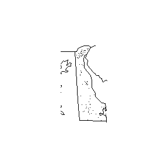

```r
setwd(system.file("extdata", package = "FRAS"))
fars_map_state(10, 2013)
```